# Project Name: Final Destination

## Group 19 (The Fast and the Furious) : Abhishek Barman, Arkav Banerjee, Harshit Bansal, Kritika Panjiar, Nishi Intwala

## Analyzing major causes of US road accidents

1. Introduction
2. Choice of grading
3. Data Processing
4. Data Analysis
5. Conclusions

### 1. Introduction

Road accidents remains the leading cause of death of people aged between 1-54 years. Even after superior advancements in technology, road accidents continue to claim thousands of life. Below are some more concerning facts-

1. More than 38,000 people die every year in crashes on U.S. roadways.
2. An additional 4.4 million are injured seriously enough to require medical attention.
3. Road crashes cost the U.S. more than $380 million in direct medical costs.

But these accidents can be prevented. To prevent these accidents we need to dive deep into the root causes of these accidents. In this project, we have tried to hypothesize and analyse the factors that we believe could cause road crashes. We have tried to answer the questions using descriptive analytics and visualizations to conclude on our hypothesis and furthermore, suggest ways to curb these causes. We hope that our insights will be helpful in raising awareness amongst citizens, policy makers which in turn will be helpful in creating guidelines and policies that promote safer road trips.

Below are the questions that we have tried to analyze and answer-

**1. Is there any relationship between the number of accidents caused and the time of the day?** : Are more accidents caused during the night? These insights will help us infer the number of accidents caused during the day. During those hours the government could implement tighter securtiy and higher number of rules. This will help curb the accidents on a daily basis.

**2. Our next question is to determine how does bad weather affect the severity of accidents?** : It makes logical sense to uncover this hypothesis. Bad weather conditions such as snow/heavy rain/mist etc could increase chances of accidents. But, is this really true? Are the rules placed for driving during bad weather effective? This is an important question we need to answer as it may shed light on our existing traffic rules system and suggest improvisations.

**3. Next we need to analyse the relationship between the number of accidents and the months of a year?** : Are there more number of accidents during the holiday seasons or are there more number of accidents during summer months when most people are out of their homes? By gaining insights on this relationship, we can customize our traffic rules. Traffic rules could be adjusted to ensure lesser number of accidents during these months.

**4. Which state has the highest accident rate and more serious accidents have taken place** : This is a critical question we need to answer before proceeding in our analysis. Do more number of accidents take place in busier states such as California or New York? Are there any states which have more severe accidents that have taken place? We need to understand the relationship between severity , number of crashes and states so we could dive down deeper and understand the cause behind the same.

**5. After analysis the states which have higher number and severity of accidents, we need to understand why these states have such high number of accidents?** : Is there any relationship between disobeying traffic rules and number of accidents? It makes sense to assume that states where traffic rules are not followed by citizens could be at a higher risk of number of accidents. Not following basic traffic signals or stop signs could trigger accidents. So our question here is does more accidents happen because drivers don't follow traffice rules? If there are certain states where people dont follow traffic rules and have a proven record of higher accidents, the states could add higher penalty to curb these occurences.

*Data Description*

To help us answer the critical questions above we have decided to work with the Crash Data Statistics available on Kaggle. Here is the link to the dataset : https://www.kaggle.com/sobhanmoosavi/us-accidents

The data set comprises of data from 49 states in the US collected from February 2016 to December 2019. The data set contains road accident data where each row represents a single accident and has 2.9 Million records. To focus on our answering our critical questions stated above, we decided to limit our crash data statistics to the year of 2016. The data has 49 columns and consists of information about the following categories :

1. Location of the crash - the state , the city , the geographical location, the street side and the nearby airport code of the crash.
2. Time of the crash - the data consists of the exact date and time stamp of the crash, the timezone it took place in and the sunset/sunrise conditions of the crash.
3. Weather conditions - the data has the exact weather conditions during the crash such as temperature, wind chill , humidity and overall weather conditions.
4. Traffic conditions - the exact traffic conditions during the crash, whether the crash took at a stop sign, a traffic signal , a bump etc.
5. Severity - Severity of the car crashes which ranges between 1-4, 1 being the lowest and 4 being the highest.

We have used these attributes in our analysis to answer our research questions.

We had also decided to use the following data set available at NHTSA website: Crash Data (2016) from National Highway Traffic Safety Administration (NHTSA)

The second dataset had additional information on fatalities occurred, state of the driver and how the crash happened. But since the level of data was inconsistent, the merging of two datasets was not done.

### 2. Choice of grading

Our project should be graded more heavily on **data analysis**.

To zero down on 5 most insightful analysis, we had to do form and test more than 10 diffrent hypothesis. In terms of pure size of data we had 49 features and over 400,000 rows. We have picked critical questions that needed answering and we had to conduct complex and in depth analysis to answer the same. Our visualisations clearly represent the questions we have asked and have been successful in giving useful insights. Since finding out useful insights is one the critical points in our analysis , it makes sense to choose data analysis as our choice of grading.

### 3. Data Processing

#### Importing necessary libraries

```python
# Importing required libraries
import numpy as np
import pandas as pd
import seaborn as sns
%matplotlib inline
import matplotlib.pyplot as plt
import re
import plotly.express as px
```

#### Importing data

```python
# Importing data
path = 'C:/Users/baner/Downloads/Python/PROJECT DATA/'
df = pd.read_csv(path + 'US_Accidents_Dec19.csv')
df.shape
```

```
(2974335, 49)
```

#### Extracting the year into a new column

```python
#Extracting year
df['Year'] = df.Start_Time.str[:4]
```

#### Extracting accidents for the year 2016

We will be conducting our analysis for the year 2016, as it has enough data for comprehensive study

```python
#Filtering for year 2016
df= df[df['Year']=="2016"]
```

```python
#Finding all the nulls for all columns
for col in df.columns:
    print(col,df[col].isnull().sum())
```

```
ID 0
Source 0
TMC 129332
Severity 0
Start_Time 0
End_Time 0
Start_Lat 0
Start_Lng 0
End_Lat 281268
End_Lng 281268
Distance(mi) 0
Description 0
Number 282412
Street 0
Side 0
City 27
County 0
State 0
Zipcode 116
Country 0
Timezone 129
Airport_Code 232
Weather_Timestamp 3255
Temperature(F) 6463
Wind_Chill(F) 369428
Humidity(%) 7023
Pressure(in) 5101
Visibility(mi) 8790
Wind_Direction 3285
Wind_Speed(mph) 77421
Precipitation(in) 373364
Weather_Condition 8567
Amenity 0
Bump 0
Crossing 0
Give_Way 0
Junction 0
No_Exit 0
Railway 0
Roundabout 0
Station 0
Stop 0
Traffic_Calming 0
Traffic_Signal 0
Turning_Loop 0
Sunrise_Sunset 27
Civil_Twilight 27
Nautical_Twilight 27
Astronomical_Twilight 27
Year 0
```

#### Cleaning City Column

We cleaned the city column by imputing the nulls. In this dataset, city inculdes towns as well.  
1) First, we found the indices of the rows where the cities are null  
2) Next, we created a list of the indices along with the cities they need to be replaced with (We have manually found this information from Google)  
3) Finally, the nulls have been imputed with the respective cities

```python
#finding where the cities are null
null_city = df[df["City"].isnull()]
#replacing the nulls with the cities
index_list = [85973,111085,119777,125053,126323,126456,127218,132635,135062,138428,141460,145312,240031,242448,2310399,2282437,
2304773,2310773,2313332,2319619,2319629,2322955,2325190,2328680,2341438,2352454,2354471]
city_list = ["Pinon Hills","Pinon Hills","Lakewood Ranch","Lakewood Ranch","Lakewood Ranch","Lakewood Ranch",
"Lakewood Ranch","Lakewood Ranch","Lakewood Ranch","Lakewood Ranch","Lakewood Ranch","Lakewood Ranch","Washington","Washington",
"Rye Brook","Rye Brook","Coral Hills","Rye Brook","Rye Brook","Lakewood Ranch","Lakewood Ranch","Rye Brook","Rye Brook",
"Rye Brook","Rye Brook","Rye Brook","Rye Brook"]
df.loc[index_list,'City'] = city_list
```

#### Cleaning Zipcode

We cleaned the zipcodes column by imputing nulls with the help of the latitude and longitude columns  
1) First we found the indices of the rows where the zipcodes are null and compiled them in a list where the indices are null  
2) Using latitude and longitude, we found the zipcodes through Google Maps  
3) Finally we replaced the nulls in the Zipcode column with their respective zipcodes

```python
#finding where the zipcodes are null
null_zipcode = df[df["Zipcode"].isnull()]
print(null_zipcode[['Start_Lat', 'Start_Lng','City']])


#creating lst of zipcode indices
index_zipcode = []
for item in null_zipcode.index:
    index_zipcode.append(item)

zipcode_list = [94941,94941,94941,94941,94025,94941,94941,34141,34141,34141,34141,34141,34141,34141,34141,33762,32952,32952,
33762,34141,34141,34141,34141,34141,34141,34141,33762,34141,34141,33762,64487,64487,94941,94941,94941,94941,94941,94941,
64487,4733,64487,64487,33762,64487,64487,33762,64487,33762,33762,33327,33328,64487,64487,64487,33762,33327,33762,33762,33327,
33327,64487,64487,64487,64487,64487,64487,33327,33327,33762,33327,33762,33327,33762,33762,70146,33327,33762,64487,64487,
33327,33327,33327,23336,33327,33327,33762,84526,85001,85001,84526,21409,21409,21409,64487,21409,16501,94941,94941,94941,
94941,94941,94941,94941,94941,94941,9494,94941,94941,94941,94941,9494,94941,94941,94941,94941,94941]

df.loc[index_zipcode,'Zipcode'] = zipcode_list
```

```
         Start_Lat   Start_Lng               City
7794     37.885376 -122.516586    Southeast Marin
13889    37.885376 -122.516586    Southeast Marin
14515    37.885376 -122.516586    Southeast Marin
16208    37.885376 -122.516586    Southeast Marin
23539    37.505482 -122.119301          San Mateo
...            ...         ...                ...
2381870  37.942480 -122.477610        Ross Valley
2382448  37.932770 -122.409590  West Contra Costa
2382621  37.942480 -122.477610        Ross Valley
2384448  37.934376 -122.433717  West Contra Costa
2388230  37.941658 -122.473099        Ross Valley

[116 rows x 3 columns]
```

#### Resetting the Index

```python
df=df.reset_index(drop = True)
df4=df.drop(columns=['ID'])
df4.shape
```

```
(410600, 49)
```

#### Cleaning Wind Direction

Similarly for wind direction, for generalizing the directions we have bucketed a few directions for consistency across the column. For example, the representation for North was both 'North' and 'N' and was changed to 'N' and most of the other wind directions were represented by letters.

```python
# Cleaning Wind Direction
dict_1 = {'North':'N','CALM':'Calm','East':'E','South':'S','West':'W','VAR':'Variable'}
df4["Wind_Direction"].replace(dict_1, inplace=True)
```

#### Cleaning Weather Conditions

```python
# Cleaning Weather Conditions
dict_2 = {'Blowing Snow':'Snow','Light Snow':'Snow','Light Snow Showers':'Snow','Heavy Snow':'Snow','Thunderstorms and Rain':'Thunderstorm',
         'Fair':'Clear','Patches of Fog':'Fog','Rain / Windy':'Rain','Low Drifting Snow':'Snow','Light Rain / Windy':'Light Rain',
         'Thunder in the Vicinity':'Thunder','Showers in the Vicinity':'Rain','Light Rain with Thunder':'Light Rain',
         'Light Rain Showers':'Light Rain','Light Freezing Rain':'Light Rain','T-Storm':'Thunderstorm','Light Fog':'Fog',
         'Mostly Cloudy':'Cloudy','Cloudy / Windy':'Cloudy','N/A Precipitation':'Rain','Heavy Thunderstorms and Snow':'Heavy Thunderstorms',
         'Heavy Thunderstorms and Rain':'Heavy Thunderstorms','Heavy T-Storm / Windy':'Heavy Thunderstorms',
         'Heavy T-Storm':'Heavy Thunderstorms','Rain Showers':'Rain','Funnel Cloud':'Cloudy','Blowing Dust / Windy':'Blowing Dust',
         'Mostly Cloudy / Windy':'Overcast','Partly Cloudy / Windy':'Partly Cloudy','Calm':'Clear','Blowing Dust':'Widespread Dust',
         'Blowing Sand':'Widespread Dust','Light Freezing Drizzle':'Light Drizzle','Light Freezing Fog':'Fog','Light Ice Pellets':'Snow',
         'Shallow Fog':'Fog','Light Drizzle':'Drizzle','Light Thunderstorms and Rain':'Thunderstorm','Light Thunderstorms and Snow':'Snow',
         'Hail':'Widespread Dust','Volcanic Ash':'Widespread Dust','Wintry Mix':'Snow','Squalls':'Snow','Heavy Drizzle':'Light Rain',
         'Sand':'Widespread Dust'}

df4["Weather_Condition"].replace(dict_2, inplace=True)

dict_4 = {'Blowing Dust':'Widespread Dust','Light Drizzle':'Drizzle'}
df4["Weather_Condition"].replace(dict_4, inplace=True)

# After cleaning weather condtion
grouped=df4.groupby(by='Weather_Condition')
```

#### Removing duplicates

```python
#Removing duplicates
df4.drop_duplicates(keep='first',inplace=True)
df4.shape
```

```
(409756, 49)
```

#### Dropping TMC, End_Lat, End_Long

```python
# As observed from the table above, columns with very high null values- TMC, End_Lat, End_Lang, will be dropped
df4.drop(['TMC'],axis=1,inplace = True)
df4.drop(['End_Lat'],axis=1,inplace = True)
df4.drop(['End_Lng'],axis=1,inplace = True)
```

```python
df4.shape
```

```
(409756, 46)
```

### 4. Data Analysis

Now that we are done with our data processing, we can move forward to the analysis part. This is the most crucial part of our project as we will be focusing on our prime objective - to uncover the reasons behind car crashes in the US. Our first step in the analysis was to take a look at the distribution of accidents across the time of day and the months.

#### Relationship between number of accidents and time of the day

We tried to identify whether there is any relationship between the number of accidents and the time of the day accident happened. To conduct this analysis we grouped number of accidents by hour of the day (24 hour format). We used line graph to show the relationship.

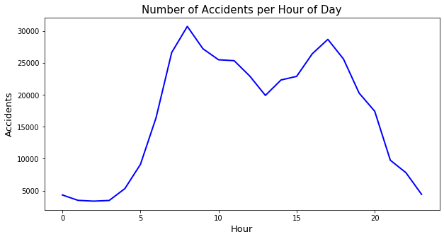

```python
#Filtering year, month and hour of crash
df4['Start_Time'] = pd.to_datetime(df4['Start_Time'])
df4['YEAR'] =  df4['Start_Time'].dt.year
df4['MONTH'] = df4['Start_Time'].dt.month
df4['HOUR']= df4['Start_Time'].dt.hour
grouped_by_hour=df4.groupby('HOUR')
count_by_hour=grouped_by_hour.count()

#Line graph to visualize
fig_size = plt.rcParams["figure.figsize"];
fig_size[0] = 10
fig_size[1] = 5
plt.rcParams["figure.figsize"] = fig_size;

dftemp=count_by_hour[['Amenity']]
dftemp.reset_index(inplace = True)
plt.plot(dftemp['HOUR'], dftemp['Amenity'], color='blue',linewidth=2, markersize=10,)
plt.title("Number of Accidents per Hour of Day", fontsize=15)
plt.xlabel('Hour', fontsize=13)
plt.ylabel('Accidents', fontsize=13)
plt.show();
```

We can see that there is a spike in accidents during 7-9 Hours and 16-18 Hours. This indicates that more number of crashes occur during rush hours(commute to office hours). This might be because more people are rushing towards their work places or rushing back to their homes. This also leads to worsened traffic conditions as there are higher number of overspeeding cases and more traffic jams. This congestion also might be contributing to the spike.

To counteract this, the government should implement tighter scrutiny. This will help curb the accidents on an hourly basis.

#### Relationship between number of accidents and bad weather

Common sense tells us that bad weather can play a role in causing accidents. We tried to see if our data tells the same.

First we need to check whether bad weather plays a hand in the severity of accidents.

For this analysis, we created two new logical columns (good_weather and bad_weather) by creating categories of "Weather_Condition" column. We categorized clear, fair and partly cloudly as good weather conditions and all values which represent heavy rain, snow and foggy conditions as bad weather conditions. We then constructed a vertical bar graph plotting the percentage of bad weather accidents per severity.

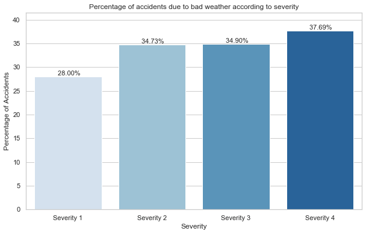

```python
# Categorizing and creation of good weather and bad weather columns
good_weather = ['Clear','Fair / Windy','Partly Cloudy','Scattered Clouds']
bad_weather = ['Fog','Heavy Rain','Heavy Thunderstorms','Overcast','Rain','Snow','Thunder','Thunderstorm','Drizzle','Cloudy','Haze','Light Rain','Mist','Smoke','Widespread Dust']
df4['good_weather'] = [1 if x in good_weather else 0 for x in df4['Weather_Condition']]
df4['bad_weather'] = [1 if x in bad_weather else 0 for x in df4['Weather_Condition']]

#Calculating proportion for severity
df_sev_1= df4[df4['Severity']==1]
df_sev_2= df4[df4['Severity']==2]
df_sev_3= df4[df4['Severity']==3]
df_sev_4= df4[df4['Severity']==4]

#calculating percentage of crashes caused due to bad weather for each severity
sev1_bw = (len(df_sev_1[df_sev_1['bad_weather']==1])/len(df_sev_1))*100
sev2_bw = (len(df_sev_2[df_sev_2['bad_weather']==1])/len(df_sev_2))*100
sev3_bw = (len(df_sev_3[df_sev_3['bad_weather']==1])/len(df_sev_3))*100
sev4_bw = (len(df_sev_4[df_sev_4['bad_weather']==1])/len(df_sev_4))*100

#Creating the visualization
values=['Severity 1','Severity 2','Severity 3','Severity 4']
frequencies= [sev1_bw,sev2_bw,sev3_bw,sev4_bw]
title = f'Percentage of accidents due to bad weather according to severity' #Title for Bar Chart
sns.set(rc={'figure.figsize':(10,6)})
sns.set_style('whitegrid')
axes = sns.barplot(x=values, y=frequencies, palette='Blues') #Assigning x-axis, y-axis and selecting Colour for the chart
axes.set_title(title)
axes.set(xlabel='Severity', ylabel='Percentage of Accidents')    #Labels for x-axis and y-axis
axes.set_ylim(top=max(frequencies) * 1.10)
axes.set_xticklabels(axes.get_xticklabels())

for bar, frequency in zip(axes.patches, frequencies):
    text_x = bar.get_x() + bar.get_width() / 2.0
    text_y = bar.get_height()
    text = f'{frequency/100: .2%}'
    axes.text(text_x, text_y, text,
              fontsize=11, ha='center', va='bottom')
```

As we can see, bad weather accounts for ~38% of Severity 4 accidents. Keeping in mind that bad weather accounts generally for about only 5-10% of the total climate in a year, their contribution increase to severe accidents is noteworthy.

We can infer that poor visibility conditions, slippery roads etc. may be one of many reasons for such rise in Severity 4 cases by bad weather.

By implementing better lighting on roads, setting lower speed limits when bad weather conditions are there may help bring down the severe accident proportion for bad weather.

#### Relationship between month of accidents and precipitation

Now that we have confirmed that bad weather leads to more severe accidents, we try to narrow down the main reason behind car crashes during bad weather according to our data. We hypothesize that Preciptation could be one of the leading causes. Hence, we have Precipitation (in inches) which can be a good indicator of whether a particular area is hit by rain/snow/hail etc during the time of the accident. So, higher the precipitation, denser the rainfall/snowfall.

So, we plot a multi y-axis line graph showing average precipitation per month and another line showing total accidents per month to see if there are any trendlines visible from the data. We chose a multi y-axis line graph because the scales for total accidents(in thousands) and preicipation (less than 1) are not same.

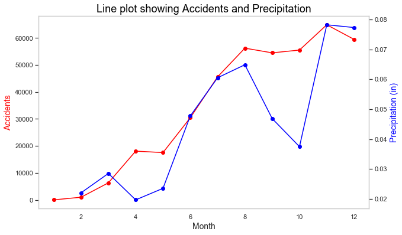

```python
#calculating count of accidents for each month
grouped=df4.groupby('MONTH')
count_by_month=grouped.count()
#calculating average precipitation by each month
mean_by_month=grouped.mean()
preci = mean_by_month[['Precipitation(in)']]
no_of_Acci= count_by_month[['Amenity']]
no_of_Acci=no_of_Acci.rename(columns={"Amenity": "Accidents"})
mergedDf = pd.merge(no_of_Acci,preci,on='MONTH', how ='outer')
mergedDf.reset_index(inplace = True)

#Creating visualization
fig,ax = plt.subplots()
ax.plot(mergedDf.MONTH, mergedDf.Accidents, color="red", marker="o")
ax.grid(False)
# set x-axis label
ax.set_xlabel("Month",fontsize=14)
# set y-axis label
ax.set_ylabel("Accidents",color="red",fontsize=14)
ax.set_title("Line plot showing Accidents and Precipitation",color="black",fontsize=18)
# twin object for two different y-axis on the sample plot
ax2=ax.twinx()
# make a plot with different y-axis using second axis object
ax2.plot(mergedDf.MONTH, mergedDf['Precipitation(in)'],color="blue",marker="o")
ax2.grid(False)
ax2.set_ylabel("Precipitation (in)",color="blue",fontsize=14)
plt.show()
```

To counter this, the government needs to focus on reducing road slipperiness. Maintenence activities like drainage repair, snow removal and street sweeping need to be ramped up. More intensive measures can be taken at slippery accident prone zones like grinding or milling a surface that has worn smooth, overlaying a new asphalt layer etc.

### Relationship between Severity of accidents and States

Our next research question is to analyse if there is any relationship betweeen the number and severity of accidents and the states. We try to find if there are some states which are more prone to higher car crashes. To do this we grouped the data using Airport Codes so that we get a count of car crashes for all airport areas. The use of Airport Codes will group all neighboring cities into one geographical location. We have then calculated the mean of the severity of crashes with respect to the Airport codes.

```python
#calculating average Severity for each airport code
group_airport = df4.groupby('Airport_Code').mean()
#creating visualizations
mapbox_access_token = 'pk.eyJ1IjoiYXJrYXZiIiwiYSI6ImNrOWhwZWJwbjEwem8zbW53Y2duY2l2M2EifQ.ryoemP7sSZHSTCVfEyVVyg'
px.set_mapbox_access_token(mapbox_access_token)

fig = px.scatter_mapbox(group_airport,
        lon = group_airport['Start_Lng'],
        lat = group_airport['Start_Lat'],

        color = 'Severity',
        size = 'Severity',

        opacity = .5,
        color_continuous_scale=px.colors.sequential.Blues, size_max=7, zoom=3)


fig.show()
```

[interactive chart not shown]

Bubbles with varying sizes represent more severe crashes. As the colour darkens the severity of the crashes increase.

We can observe that Eastern states have far more crashes than the western states. There is a cluster of very high number of severe crashes in Colorado. Surprisingly, the severity of crashes in busier and more populous states such as California and New York is far lesser than we would expect. We can observe that states such as Nebraska, North Dakota, Nevada, Montana have very less number of accidents. In the next steps we will analyse the reasons behind high/low severity of car crashes in each state.

### Top reason for accidents by state

Now that we have an overview of the states with higher cases of more severe accidents, our next reasearch question is to understand why these states have such high number of accidents. To decode this we decided to look at the traffic conditions attributes when the accident took place. We decided to take a look at accidents which take place at Stop Signs or Traffic Signals. Many people have the tendency to not follow traffic rules such as skipping traffic signals or not stopping at stop signs. We have considered these attributes as human errors.

We found the percentage of car crashes taking place at stop signs and traffic signals for each state so we could rank each states on the percentage.

```python
#creating new column for crashes which took place at stop signs or Traffic signals
df4['human_error'] = np.where((df4['Stop'] == True) | (df4['Traffic_Signal'] == True), True, False)

state_human=df4.groupby('State')
human_error_count=state_human['human_error'].count()
df_human_error_count = pd.DataFrame(data=human_error_count)

state_human_true= df4[df4['human_error']==True]
true_ones=state_human_true.groupby('State')
true_ones_count=true_ones['human_error'].count()
df_true_ones_count= pd.DataFrame(data=true_ones_count)


mergedDf = pd.merge(df_human_error_count,df_true_ones_count,on='State', how ='outer')
mergedDf['Percentage_of_accidents_caused_due_to_negligence_for_each_state'] = mergedDf['human_error_y']/mergedDf['human_error_x']*100
mergedDf = mergedDf.sort_values(by=['Percentage_of_accidents_caused_due_to_negligence_for_each_state'],ascending=False).head(10)
```

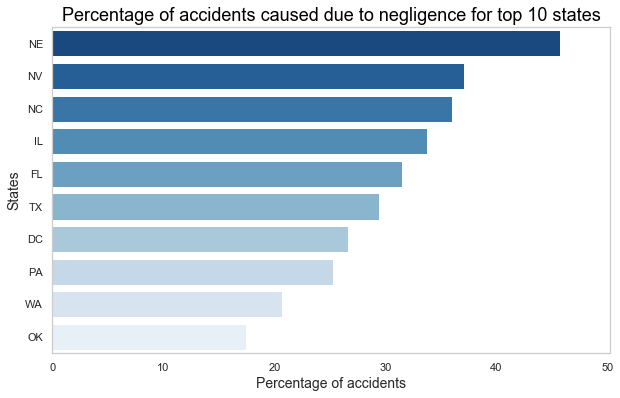

```python
#creating visualizations
frequencies= mergedDf['Percentage_of_accidents_caused_due_to_negligence_for_each_state']
values= mergedDf.index
title = 'Percentage of accidents caused due to negligence for top 10 states' #Title for Bar Chart
sns.set_style('whitegrid')
axes = sns.barplot(x=frequencies, y=values,palette="Blues_r") #Horizontal
axes.set_title(title,color="black",fontsize=18)
axes.set(xlabel='Percentage of accidents', ylabel='States')    #Labels for x-axis and y-axis
axes.xaxis.get_label().set_fontsize(14)
axes.yaxis.get_label().set_fontsize(14)
axes.grid(False)
axes.set_xlim(right=max(frequencies) * 1.10);
```

But what is most surprising is that Nebraska had very few car crashes cases but still has the highest percentage of accidents caused due to negligence. This shows that the citizens of Nebraska do not tend to follow traffic rules. Such states could implement tighter rules and penalize more for disobeying the law.

# Conclusion

Self driving cars is one of the most promising solution we have but with all the regulations and economic concerns around it, it is safe to say that they are years away from becoming mass solution.

From our dataset, after cleaning and analyzing we can draw conclusions mentioned below from our questions:

### Future Prospective

Our analysis is limited to bad weather and the description of the roads, we can make a more comprehensive and rounded analysis if we have more information on the driver. For example, their age and gender. Knowledge about prior DUI’s and whether it was a case of drunk driving can also help in a detailed statistical analysis.